# Introduction to R

28 August 2017

Throughout the course we will be using Rstudio, which is a program that provides with a convenient interface to work with R.

R code can be saved into text documents, called scripts (usually with a file extension `.R`). In this course we will be using a special kind of document, which is also text-based but mixes code and text. These are called “Rmarkdown” files (with extension `.Rmd`).

We will learn about “Rmarkdown” scripts throughout the course, but there are some useful “Cheatsheets” that are available from Rstudio itself under “Help > Cheatsheets”

These materials are inspired by these  
[Data Carpentry materials](http://www.datacarpentry.org/R-ecology-lesson/index.html). Those materials can be used to go more in-depth into several topics introduced here.

Tipically we start our analysis from data that was collected in a tabular format (for example, using Excel).

Let’s say we collected some morphometric measurements from different species over many years and want to summarise these data (for example calculate means) by species, year, sex, etc…

These data are stored in a *CSV* file in our course materials `Day1/data` folder called `surveys_data_short.csv`. Feel free to inspect that file using a spreadsheet program.

Here are the first few rows of that table:

| year | species_id | sex | hindfoot_length | weight | genus | species | taxa |
| --- | --- | --- | --- | --- | --- | --- | --- |
| 1978 | NL | M | 32 | 204 | Neotoma | albigula | Rodent |
| 1978 | NL | M | 34 | 199 | Neotoma | albigula | Rodent |
| 1978 | NL | M | 32 | 197 | Neotoma | albigula | Rodent |
| 1979 | NL | M | 33 | 166 | Neotoma | albigula | Rodent |
| 1979 | NL | M | 32 | 184 | Neotoma | albigula | Rodent |
| 1979 | NL | M | 32 | 206 | Neotoma | albigula | Rodent |

The whole dataset contains 3156 rows of data, which is reasonably big! Let’s say that, by the end of today we’d like to:

- visualise the correlation between hindfoot length and weight of each individual using a scatterplot

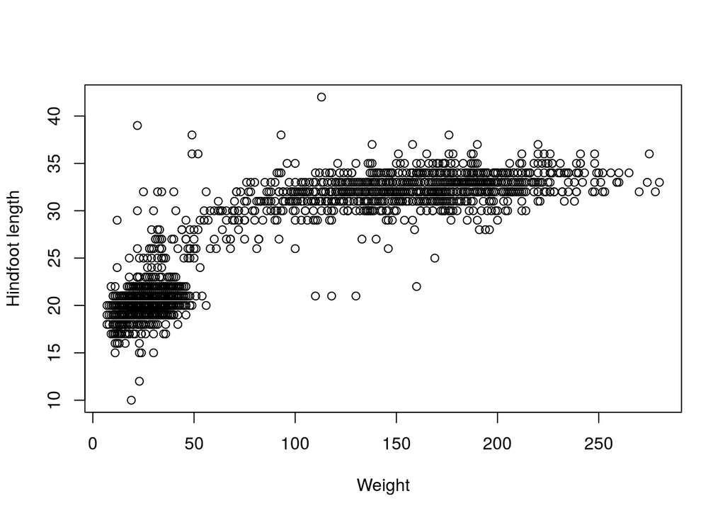

- Summarise these data into a smaller table with the mean weight and hindfoot length of each species and each sex to produce the following two plots:

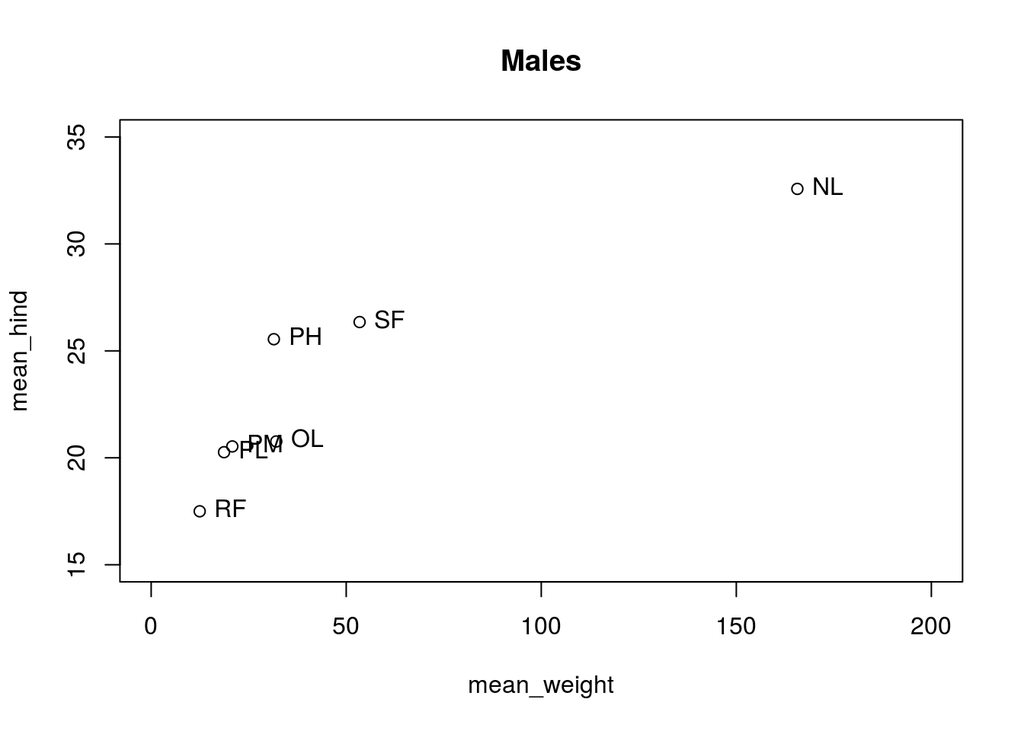

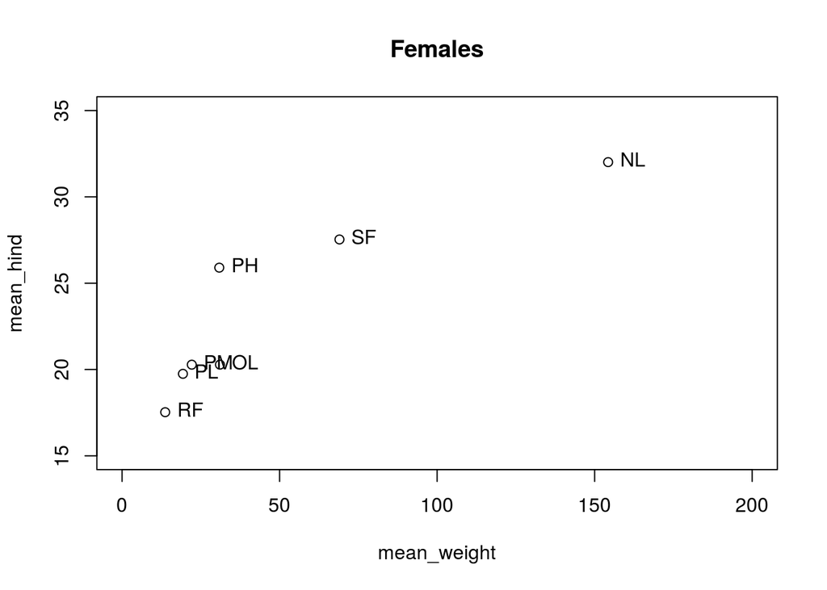

# R basics

Before we start with our analysis, let’s learn some very basic concepts in R, including:

- How to issue commands in R
- What is a variable and how to create one
- What are functions and how to use them
- What is a vector and how to create one
- What is a data.frame and how to create one from a file

### Using the console

R works by writting commands (instructions) in the *Console* that are then interpreted and executed by R, so that an answer is printed back to the user.

For example, we can use R as a calculator:

```r
# All the basic arithmetic operators in R
3 + 2    # sum
```

```
## [1] 5
```

```r
3 - 2    # subtraction
```

```
## [1] 1
```

```r
3 * 2    # multiplication
```

```
## [1] 6
```

```r
3 / 2    # division
```

```
## [1] 1.5
```

```r
3 ^ 2    # exponentiation
```

```
## [1] 9
```

### Defining variables

We can also store the result of an operation in a *variable* or *object* - basically something that we give a name to and that will contain that result for later use.

To store the result of some operation in a variable we use `<-`, which we can think of as an arrow pointing left (note: no spaces between `<` and `-`!).

```r
# Store the result of this operation in a variable called "x"
x <- 3 + 2
```

We can then re-use this variable again an again, for example:

```r
x + 1
```

```
## [1] 6
```

```r
x + 2
```

```
## [1] 7
```

```r
x * 2 + 3
```

```
## [1] 13
```

Note that the value of `x` itself did not change:

```r
x
```

```
## [1] 5
```

But we can change its value by “over-writing” it with a new value:

```r
x <- 6
```

Note that the previous value of `x` is lost. If we want it back we’d have to run our previous commands again.

> What do you think the value of `x` is after the following command?

```r
x <- x + 1
```

### Functions

A lot of the functionality in R is in its functions, which allow us to perform certain operations (sometimes very complicated ones) with a single command.

We can recognise functions in code easily, because they always follow the pattern:

`function(inputs)`

that is, we have the function name, then open parenthesis, and inside the parenthesis we include all the necessary inputs (arguments) that the function needs to perform its operations.

We will come across many functions throughout the course, but here’s a few examples of functions that operate on a single number:

```r
# Square root of 3
sqrt(3)
```

```
## [1] 1.732051
```

```r
# Round 3.14
round(3.14)
```

```
## [1] 3
```

We can see that the round function rounds our number to the nearest integer (no decimal points). However, we might want to round the number to one, or two, or three, etc., decimal points instead. In fact, we can do this with the `round()` function, because it accepts extra *arguments* as its input:

```r
# Round 3.14 to the nearest digit
round(3.14, digits = 1)
```

```
## [1] 3.1
```

Arguments within functions are separated by a comma `,`.

But how would we know what that option was called? Or that it even existed?

The answer is: by looking at its documentation. Every function in R has a help page, which we can look at by using `?` followed by the function’s name, for example `?round`.

From its help page we can see that this function accepts two arguments called “x” and “digits”. “x” is the number we want to round, and “digits” is the number of decimal points we want to round to.

> Use these examples to understand more about how functions work:

```r
round(x = 2.72, digits = 1)
```

```
## [1] 2.7
```

```r
round(digits = 1, x = 2.72)
```

```
## [1] 2.7
```

```r
round(2.72, 1)
```

```
## [1] 2.7
```

```r
round(1, 2.72)
```

```
## [1] 1
```

### Vectors - the most basic data type in R

In the previous examples, we created variables that contained a single value. But sometimes we might want to manipulate and store several values together to perform certain operations on.

We can achieve this by creating what is called a *vector*, which is the most fundamental data type in R. For this we use a special function in R simply called `c()` (for “combine”), like so:

```r
y <- c(1, 3, 5, 6)
y
```

```
## [1] 1 3 5 6
```

As you see, `y` now contains four values.

> Use the following code to understand the behaviour of vectors:

```r
y + 1
```

```
## [1] 2 4 6 7
```

```r
y + y
```

```
## [1]  2  6 10 12
```

```r
y + c(1, 2)
```

```
## [1] 2 5 6 8
```

### Subsetting vectors

You can access specific values within a vector by using `[]`, like so:

```r
# Get the first element of y
y[1]
```

```
## [1] 1
```

```r
# Get the second element of y
y[2]
```

```
## [1] 3
```

```r
# Get the first and third elements of y
y[c(1, 3)]
```

```
## [1] 1 5
```

Can you see what we did with that last command? We used a vector to subset another vector! This is an often used trick, and we will learn more about it later.

> Using `[]` and `c()`, can you return all the values in `y` but in reverse order?

# Starting our analysis

Now we know the very basics or R, we will learn more about it by working through our species dataset.

To reach our goal we will try to do the following in R:

- Read our tabular data from a file
- Manipulate this table within R
- Get an overview of the data
- Summarise our data by different groups
- Make our desired plot

To this end we will use a package in R called `tidyverse`. Packages are collections of functions that extend the functionality of R. The package that we’re going to use, for example, contains several functions that facilitate manipulating tables in R.

To make the functions in a package available we need to “load” it, like so:

```r
library(tidyverse)
```

If the package is not installed, then you can install it by using the command `install.packages("package_name")` (replacing “package_name” with the name of the package you want to install). This will download the package from the internet and install it on your computer.

### Reading tabular data from a file

To read files into R, we first need to learn how to tell the program where our file is (without using the file browser!).

This is done by specifying the **path** to that file. This is like an address of where that file is located on the computer.

File paths are built like so:

```
directory/subdirectory/another_subdirectory/some_file.txt
```

- Each directory is split by a `/`
- The file name comes at the end (don’t forget to include the file extension!)
- Spaces should be avoided, but in R they are tolerated

But what is the starting point of this *path*?

This varies between operating system, but generally a good way to start is to look at the **working directory** that R is using. This is the *path* that R is taking as a reference point while you are working. Try:

```r
getwd()
```

If you’re not working with a “Rmarkdown” file, then it’s a good idea to set a working directory that corresponds to your project folder. We do this with the `setwd()` function, for example:

```r
setwd("~/Desktop/course_materials/Day1")
```

- The `~` means “home directory”, which is a specific directory that corresponds to your user account on the computer (again, this varies between operating system).

> To read a `CSV` file into R, we will use the function `read_csv()`.

> Inside the parentises you need to put the path to the file you want to read within quotes.
> - Read the file called “surveys_data_short.csv” located in the “data” folder.
> - Assign the result to an object called `surveys`.
> - What kind of object is it? *Hint:* use the function `class()`.

```r
# Complete this code:
surveys <- read_csv("<here>")
class(<here>)
```

### The data.frame object

Tabular objects in R are tipically stored in **data.frame** objects. In our case, the object is also a “tibble” object, which is a special type of “data.frame” that, for all practical purposes in this lesson, is equivalent.

After reading data into R it’s always good to check the data. Several functions can help with this:

```r
nrow(surveys)     # number of rows
```

```
## [1] 3156
```

```r
ncol(surveys)     # number of columns
```

```
## [1] 8
```

```r
head(surveys)     # the first few rows of data
```

```
## # A tibble: 6 x 8
##    year species_id   sex hindfoot_length weight   genus  species   taxa
##   <int>      <chr> <chr>           <int>  <int>   <chr>    <chr>  <chr>
## 1  1978         NL     M              NA    218 Neotoma albigula Rodent
## 2  1978         NL     M              32    204 Neotoma albigula Rodent
## 3  1978         NL     M              NA    200 Neotoma albigula Rodent
## 4  1978         NL     M              34    199 Neotoma albigula Rodent
## 5  1978         NL     M              32    197 Neotoma albigula Rodent
## 6  1978         NL     M              NA    218 Neotoma albigula Rodent
```

We’ve learned how to subset vectors in R by using `[]`. We can subset data.frames in the same way, except that now we need to define two dimensions: rows and columns.

With a data.frame we use the syntax: `[row, column]`. For example, if I wanted the first 3 rows and the first 2 columns of my table, I could do:

```r
surveys[c(1, 2, 3), c(1, 2)]
```

```
## # A tibble: 3 x 2
##    year species_id
##   <int>      <chr>
## 1  1978         NL
## 2  1978         NL
## 3  1978         NL
```

If I wanted the first 3 rows and *all* columns, I would put nothing on the right of the comma:

```r
surveys[c(1, 2, 3), ]
```

```
## # A tibble: 3 x 8
##    year species_id   sex hindfoot_length weight   genus  species   taxa
##   <int>      <chr> <chr>           <int>  <int>   <chr>    <chr>  <chr>
## 1  1978         NL     M              NA    218 Neotoma albigula Rodent
## 2  1978         NL     M              32    204 Neotoma albigula Rodent
## 3  1978         NL     M              NA    200 Neotoma albigula Rodent
```

And vice-versa for rows (let’s not run this command, because there’s 3156, rows in our table!):

```r
surveys[, c(1, 2)]
```

**Tip**

Let’s say I wanted rows 11 to 30 of my table. How could I do this? With what we’ve learned so far, this would be the solution:

```r
surveys[c(11, 12, 13, 14, 15, 16, 17, 18, 19, 20, 21, 22, 23, 24, 25, 26, 27, 28, 29, 30), ]
```

```
## # A tibble: 20 x 8
##     year species_id   sex hindfoot_length weight   genus  species   taxa
##    <int>      <chr> <chr>           <int>  <int>   <chr>    <chr>  <chr>
##  1  1979         NL     F              30    186 Neotoma albigula Rodent
##  2  1980         NL     F              33    184 Neotoma albigula Rodent
##  3  1980         NL     F              31     87 Neotoma albigula Rodent
##  4  1980         NL     F              33    174 Neotoma albigula Rodent
##  5  1981         NL     F              30    130 Neotoma albigula Rodent
##  6  1981         NL     M              34    208 Neotoma albigula Rodent
##  7  1981         NL     M              34    192 Neotoma albigula Rodent
##  8  1982         NL     M              NA    206 Neotoma albigula Rodent
##  9  1982         NL     F              32    165 Neotoma albigula Rodent
## 10  1982         NL     M              34    202 Neotoma albigula Rodent
## 11  1982         NL     M              33    211 Neotoma albigula Rodent
## 12  1982         NL     M              31    120 Neotoma albigula Rodent
## 13  1982         NL     F              32     40 Neotoma albigula Rodent
## 14  1982         NL     M              33    222 Neotoma albigula Rodent
## 15  1982         NL     F              30    100 Neotoma albigula Rodent
## 16  1982         NL     F              33    120 Neotoma albigula Rodent
## 17  1982         NL     M              NA    219 Neotoma albigula Rodent
## 18  1982         NL     F              31    112 Neotoma albigula Rodent
## 19  1982         NL     F              33    152 Neotoma albigula Rodent
## 20  1983         NL     F              30    126 Neotoma albigula Rodent
```

But that’s a lot of typing!! In fact, creating a sequence of whole numbers incrementing by 1 is such a common thing, that there is a compact way to do it:

```r
1:10 # sequence from 1 to 10
```

```
##  [1]  1  2  3  4  5  6  7  8  9 10
```

```r
10:1 # sequence from 10 to 1
```

```
##  [1] 10  9  8  7  6  5  4  3  2  1
```

> Having this information, create a new data.frame object called `surveys_subset` containing rows 181 to 200 from the original table.

```r
# put your code here!
```

It’s also possible to create more complex sequences of numbers, using a function called `seq()`:

```r
seq(from = 1, to = 10, by = 2)  # sequence of numbers from 1 to 10 incrementing by 2
```

```
## [1] 1 3 5 7 9
```

```r
seq(10, 1, -2)                  # sequence of numbers from 10 to 1 decreasing by 2
```

```
## [1] 10  8  6  4  2
```

### Accessing variables in data.frames

Because columns in our data.frames are named variables (the things we measured), it is convenient to access them by name, rather than by position using `[]`.

Individual columns can be accessed using the `$` operator, like so:

```r
surveys$weight
```

> What kind of object do you think is returned?

The variables (columns) in a data.frame are in fact vectors, which we’ve already learned to manipulate!

So, for example, if I wanted the first 20 values of weight I could do:

```r
surveys$weight[1:20]
```

```
##  [1] 218 204 200 199 197 218 166 184 206 274 186 184  87 174 130 208 192
## [18] 206 165 202
```

We can also select several variables using the function `select()`, from the `dplyr` package (part of `tidyverse`):

```r
select(surveys, species_id, weight)
```

> What kind of object do you think is returned in this case?

### A simple plot

We are finally ready to produce our desired scatterplot. We will learn more about plotting on Day 2 of the course, but for now we will use the `plot()` function, which needs at least two arguments: the values for the x-axis and the values for the y-axis:

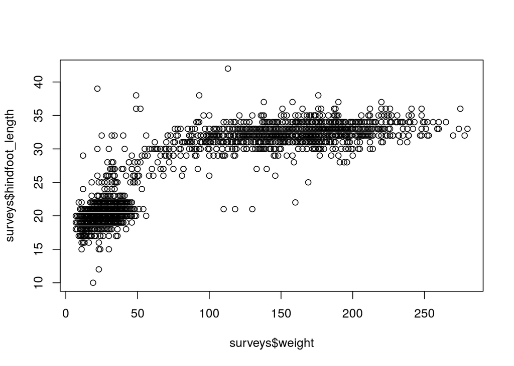

```r
plot(surveys$weight, surveys$hindfoot_length)
```

# Some key points to remember

- Vectors are the most fundamental data type in R. They have one dimension only.
  - Subset vectors using `[]`
- data.frames are the default tabular object in R. Thave have two dimensions (observations in rows and variables in columns).
  - Read them into R using the `read_*` family of functions
  - Subset data.frames using `[row, column]`
  - Access individual columns using `$` (the result is a vector)
  - Access several columns using `select()` (the result is a data.frame)